# Análisis de Fortaleza Partidaria en Elecciones Municipales Chilenas (1992-2024)

# 4 Índice de Fortaleza Institucional Partidaria (PISI)

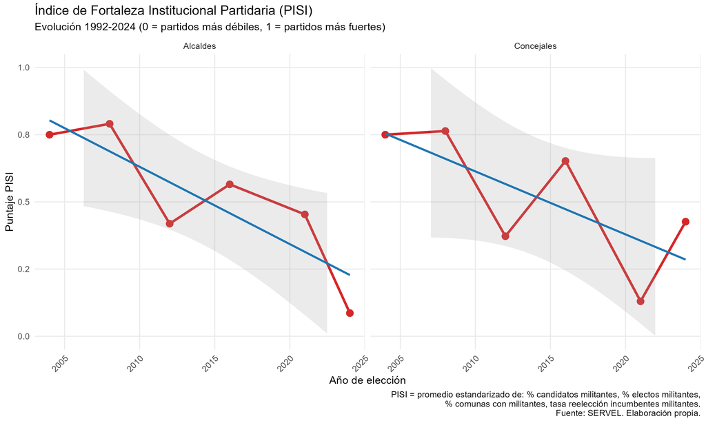

El PISI muestra la evolución de la fortaleza institucional partidaria. Valores cercanos a 1 indican partidos más fuertes, mientras que valores cercanos a 0 sugieren mayor debilitamiento partidario.

Evolución del PISI - Alcaldes

| Año | Puntaje PISI | Cambio |
| --- | --- | --- |
| 2004 | 0.750 | NA |
| 2008 | 0.791 | 0.041 |
| 2012 | 0.419 | -0.372 |
| 2016 | 0.565 | 0.146 |
| 2021 | 0.453 | -0.112 |
| 2024 | 0.086 | -0.367 |

```
## El PISI muestra una tendencia descendente con una pendiente de 0.0288 puntos por año. Esto sugiere un debilitamiento gradual de la fortaleza partidaria.
```

# 5 Continuidad y Reelección

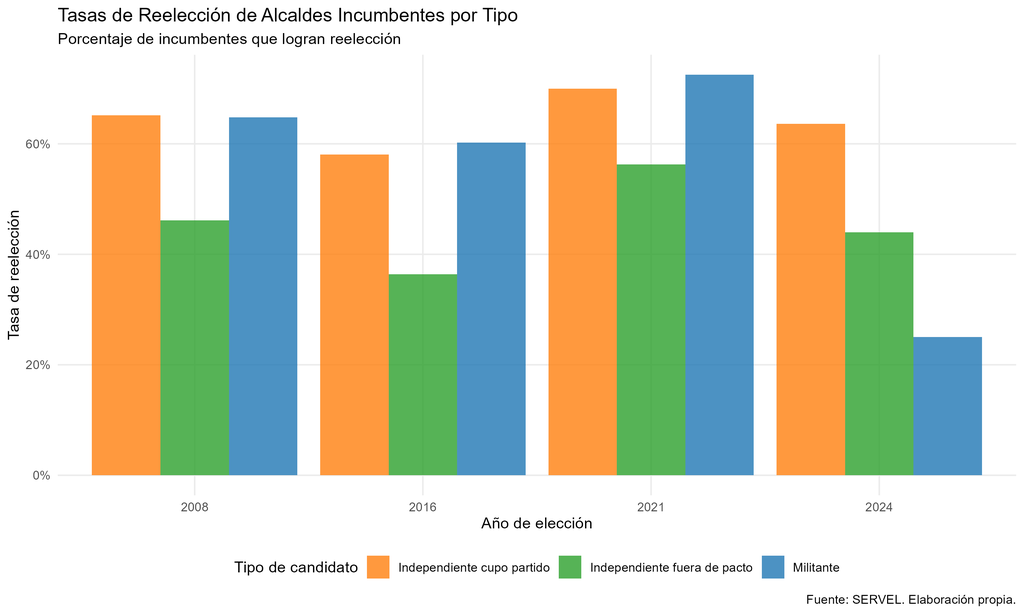

Comparación de las tasas de reelección entre diferentes tipos de incumbentes. Muestra la capacidad de cada tipo de candidatura para mantener el poder una vez alcanzado.

# 6 Dinámicas de Cambio

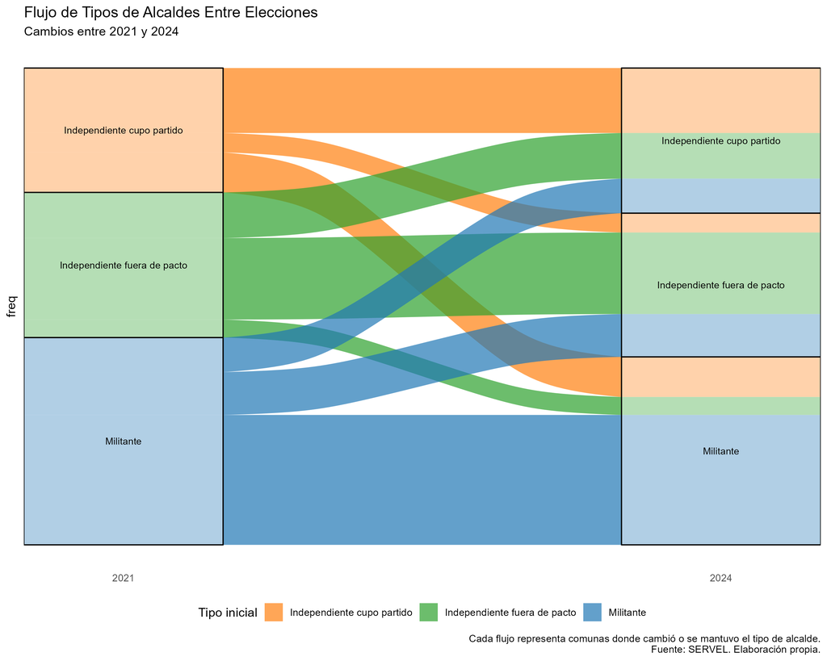

Diagrama de flujo mostrando cómo han cambiado los tipos de alcaldes electos entre elecciones consecutivas. Cada flujo representa comunas donde se mantuvo o cambió el tipo de alcalde.

Matriz de transición de tipos de alcaldes entre 2021 y 2024 (número de comunas)

| Tipo 2021 | Independiente cupo partido | Independiente fuera de pacto | Militante | Total_2021 |
| --- | --- | --- | --- | --- |
| Independiente cupo partido | 47 | 14 | 29 | 90 |
| Independiente fuera de pacto | 33 | 59 | 13 | 105 |
| Militante | 25 | 31 | 94 | 150 |
| Total 2024 | 105 | 104 | 136 | 345 |

Resumen de cambios en alcaldes militantes (2021-2024)

| Indicador | Valor |
| --- | --- |
| Total comunas analizadas | 345 |
| Alcaldes militantes 2021 | 150 (43.5%) |
| Alcaldes militantes 2024 | 136 (39.4%) |
| Cambio neto militantes | -14 comunas |
| Tasa de retención militantes | 62.7% |

Los flujos entre 2021 y 2024 revelan un debilitamiento significativo de la presencia de alcaldes militantes en las comunas chilenas. Los partidos políticos perdieron presencia en 14 comunas netas, pasando de controlar 150 alcaldías (43.5%) a solo 136 (39.4%). Este retroceso se explica por una baja capacidad de retención: solo el 62.7% de las comunas con alcaldes militantes en 2021 mantuvieron este tipo de liderazgo, mientras que 56 comunas transitaron hacia alcaldes independientes. Es particularmente notable que la mayoría de las pérdidas (31 comunas) fueron hacia independientes fuera de pacto, sugiriendo un rechazo más profundo a las estructuras partidarias tradicionales. Si bien los partidos lograron recuperar 42 comunas (principalmente desde independientes en cupo de partido), este flujo de entrada no fue suficiente para compensar las salidas. Estos datos confirman una tendencia sostenida de despartidización de la política local chilena, donde los electores privilegian candidaturas independientes por sobre las afiliaciones partidarias tradicionales.

# 7 Conclusiones

1. **Diversificación de candidaturas**: La proporción de candidatos militantes a alcalde disminuyó en 15.8 puntos porcentuales entre 2004 y 2024.
2. **Fortaleza institucional**: El PISI disminuyó en 0.664 puntos entre 2004 y 2024, suggeriendo una erosión de la fortaleza partidaria.

**Laboratorio Municipal** | Análisis de Fortaleza Partidaria en Elecciones Municipales Chilenas

*Generado el 2025-09-17 | Datos actualizados hasta 2024*